# A Practical Introduction to Collostructional Analysis in R

A Practical Introduction to Collostructional Analysis in R Alvin Cheng-Hsien Chen October 7, 2025 @ NCCU  
👉 [Launch Tutorial in Binder](https://mybinder.org/v2/gh/alvinntnu/collostruction_tutorial/main?urlpath=rstudio)

👉 [Launch Tutorial in Binder](https://mybinder.org/v2/gh/alvinntnu/collostruction_tutorial/main?urlpath=rstudio)

## 1 Loading packages

```r
library(tidyverse)
library(tidytext)
library(quanteda)
library(stringr)
library(jiebaR)
library(readtext)
```

## 2 Objectives

In this tutorial, I would like to talk about the relationship between a construction and words. Words may co-occur to form **collocation** patterns. When words co-occur with a particular morphosyntactic pattern, they would form **collostruction** patterns.

Here I would like to introduce a widely-applied method for research on the meanings of constructional schemas—**Collostructional Aanalysis** (Stefanowitsch & Gries, 2003). This is the major framework in corpus linguistics for the study of the relationship between words and constructions.

The idea behind collostructional analysis is simple: the meaning of a morphosyntactic construction can be determined very often by its co-occurring words.

In particular, words that are strongly associated (i.e., co-occurring) with the construction are referred to as **collexemes** of the construction.

**Collostructional Analysis** is an umbrella term, which covers several sub-analyses for constructional semantics:

- **Collexeme** Analysis (cf. Stefanowitsch & Gries (2003))
- **Co-varying Collexeme** Analysis (cf. Stefanowitsch & Gries (2005))
- **(Multiple) Distinctive Collexeme** Analysis (cf. Stefan T. Gries & Stefanowitsch (2004))

This tutorial will first focus on **collexeme analysis**, whose principles can be extended to the other analyses.

Also, I will demonstrate how we can conduct a collexeme analysis by using the R script written by Stefan Gries ([Collostructional Analysis](http://www.stgries.info/teaching/groningen/index.html)).

## 3 Corpus

As a demonstration, we use the Apple News Corpus (`demo_data/applenews10000.tar.gz`).

Our target is the Chinese construction `X + 起來`. The goal is to discover which words most frequently fill the `X` slot and what this reveals about the semantics of the construction.

That is, we want to identify the collexemes of `X + 起來` and examine how coherent they are in meaning.

We begin by loading the corpus and creating a `corpus` object.

```r
## Load Data
apple_df <-
  readtext("demo_data/applenews10000.tar.gz", encoding = "UTF-8") %>% ## loading data
  filter(!str_detect(text, "^\\s*$")) %>% ## removing empty docs
  mutate(doc_id = row_number()) ## create index
```

Raw texts often contain unwanted characters such as invisible **control codes**, **extra spaces**, or **duplicate line breaks**.

These can interfere with segmentation accuracy. It is therefore a good idea to clean the texts before tokenization.

Here we used a simple function, `normalize_document()`, but you can always design a more specialized version for your own data.

- Define how we would like to preprocess the data:

```r
## Text normalization function
## Define a function
normalize_document <- function(texts) {
  texts %>%
    str_replace_all("\\p{C}", " ") %>%  ## remove control chars
    str_replace_all("[\\s|\\n]+", " ") %>%  ## replace whitespaces/linebreaks with one whitespace
    trimws
}
```

- An example:

```r
## Example usage of `normalize_document()`
## before cleaning
apple_df$text[1]
```

```
## [1] "《蘋果體育》即日起進行虛擬賭盤擂台，每名受邀參賽者進行勝負預測，每周結算在周二公布，累積勝率前3高參賽者可繼續參賽，單周勝率最高者，將加封「蘋果波神」頭銜。註:賭盤賠率如有變動，以台灣運彩為主。\n資料來源：NBA官網http://www.nba.com\n\n金塊(客) 103：92 76人騎士(主) 88：82 快艇活塞(客) 92：75 公牛勇士(客) 108：82 灰熊熱火(客) 103：82 灰狼籃網(客) 90：82 公鹿溜馬(客) 111：100 馬刺國王(客) 112：102 爵士小牛(客) 108：106 拓荒者\n\n"
```

```r
## after cleaning
normalize_document(apple_df$text[1])
```

```
## [1] "《蘋果體育》即日起進行虛擬賭盤擂台，每名受邀參賽者進行勝負預測，每周結算在周二公布，累積勝率前3高參賽者可繼續參賽，單周勝率最高者，將加封「蘋果波神」頭銜。註:賭盤賠率如有變動，以台灣運彩為主。 資料來源：NBA官網http://www.nba.com 金塊(客) 103：92 76人騎士(主) 88：82 快艇活塞(客) 92：75 公牛勇士(客) 108：82 灰熊熱火(客) 103：82 灰狼籃網(客) 90：82 公鹿溜馬(客) 111：100 馬刺國王(客) 112：102 爵士小牛(客) 108：106 拓荒者"
```

- Preprocess all texts in the corpus

```r
## Apply cleaning to all docs
apple_df$text <- normalize_document(apple_df$text)
```

|  | doc_id | text |
| --- | --- | --- |
| 1 | 1 | 《蘋果體育》即日起進行虛擬賭盤擂台，每名受邀參賽者進行勝負預測，每周結算在周二公布，累積勝率前3高參賽者可繼續參賽，單周勝率最高者，將加封「蘋果波神」頭銜。註:賭盤賠率如有變動，以台灣運彩為主。 資料... |
| 2 | 2 | 【動新聞╱綜合報導】新北市一名18歲李姓男子，疑因女友要分手，避不見面也不接電話，他為見女友一面，挽回感情，竟學蜘蛛人攀爬鐵窗，欲潛入女友位於5樓住處，行經2樓時被住戶發現，他誆稱「撿鑰匙」矇混過關，... |
| 3 | 3 | 水母是一種低等動物，屬於大型浮游生物，而「水母腦」則是貶義詞，形容一個人像水母般一樣無腦的意思，想知道你的水母腦指數有多高嗎？快來玩阿波羅老師的趣味占卜吧！報導╱周佩儀 請選出你最喜歡的帽款。 你的外... |
| 4 | 4 | 【高佳菁╱台北報導】台股昨一度突破8500點，再創28個月來新高，但因追價力道不足，終場收小黑，未能延續漲勢，今年來指數漲幅逾9%，但台股基金表現更搶眼，整體平均報酬約18%左右，是大盤指數的1倍，且... |
| 5 | 5 | 在台北破20萬人次的Robot Kitty未來樂園，12/14將在高雄開展！《蘋果日報》搶先帶逛，三麗鷗家族Hello Kitty、美樂蒂等將化身部門主管，分別有設計、零件、品管、維修、能源5大互動遊... |
| 6 | 6 | 【施鈺文╱台北報導】最新一期《壹週刊》披露已婚的民進黨籍台北市議員田欣，與其相差十七歲的女助理呂玨音爆發婚外情。田欣昨表示：「要好好面對及處理自己家庭內的問題。」田欣妻子黃儀倩昨則發表聲明痛批「田欣一... |
| 7 | 7 | http://www.appledaily.com.tw/realtimenews/forum... |
| 8 | 8 | 台北市 蔡小姐 日前下載遠傳App，瀏覽帳單明細時突然發現有個「小額代繳199元」項目，詢問客服人員，客服指她在去年11月經由線上申請遠傳線上看片服務，且申請1年。但她根本沒用過這項服務，既然簽1年約... |
| 9 | 9 | 【娛樂中心╱台北報導】蕭淑慎在圈內爆出的戀情，對象從七十七歲的大老闆到只有二十二歲的小帥哥，用「日新又新」來形容並不誇張。雖然她給人的形象多半是「直言不諱」，但只要涉及「感情」這玩意，她都會有所保留。... |
| 10 | 10 | 日月明功虐死案，陳巧明等5人收押，網友Edward Chiang在台大批踢踢實業坊留言板評論。 柯文哲自喻，如果讓他加入民進黨，就如同把獅子趕進籠子裡。爭取民進黨提名的顧立雄不甘示弱，以此回擊柯文哲。... |

[output cut: 90 more lines]

## 4 Word Segmentation

Next we segment the texts into words using `jiebaR.` The steps are:

- Initialize a `jiebar` segmentation model with `worker()`.
- Define a function `word_seg_text()` to tokenize the text and, if needed, add POS tags.
- Apply this function to all texts and create a new column containing the segmented strings.

This new column will serve as the basis for later construction extraction.

```r
# Initialize jiebar
segmenter <- worker(user = "demo_data/dict-ch-user.txt",
                    bylines = F, ## ignore lines
                    symbol = F)  ## ignore symbols
```

```r
# Define function
word_seg_text <- function(text, jiebar) {
  segment(as.character(text), jiebar) %>% # word tokenize
    str_c(collapse = " ") ## concatenate word tokens into long strings
}
```

```r
# Apply the function
apple_df <- apple_df %>%
  mutate(text_tag = map_chr(text, ~ word_seg_text(.x, segmenter)))
```

The function `word_seg_text()` tokenizes Chinese text into words and produces an enriched version of the text with explicit word boundaries.

```r
word_seg_text(apple_df$text[1], segmenter)
```

```
## [1] "蘋果 體育 即日起 進行 虛擬 賭盤 擂台 每名 受邀 參賽者 進行 勝負 預測 每周 結算 在 周二 公布 累積 勝率 前 3 高 參賽者 可 繼續 參賽 單周 勝率 最高者 將 加封 蘋果 波神 頭銜 註 賭盤 賠率 如有 變動 以 台灣 運彩 為主 資料 來源 NBA 官網 http www nba com 金塊 客 103 92 76 人 騎士 主 88 82 快艇 活塞 客 92 75 公牛 勇士 客 108 82 灰熊 熱火 客 103 82 灰狼 籃網 客 90 82 公鹿 溜 馬 客 111 100 馬刺 國王 客 112 102 爵士 小牛 客 108 106…
```

In this example we did not add POS tags in order to keep things simple. For actual research, POS information can be very useful for retrieving constructions more accurately. You may therefore want to adapt both the `word_seg_text()` function and the `worker()` model to include POS tagging.

|  | doc_id | text | text_tag |
| --- | --- | --- | --- |
| 1 | 1 | 《蘋果體育》即日起進行虛擬賭盤擂台，每名受邀參賽者進行勝負預測，每周結算在周二公布，累積勝率前3高參賽者可繼續參賽，單周勝率最高者，將加封「蘋果波神」頭銜。註:賭盤賠率如有變動，以台灣運彩為主。 資料... | 蘋果 體育 即日起 進行 虛擬 賭盤 擂台 每名 受邀 參賽者 進行 勝負 預測 每周 結算 在 周二 公布 累積 勝率 前 3 高 參賽者 可 繼續 參賽 單周 勝率 最高者 將 加封 蘋果 波神 ... |
| 2 | 2 | 【動新聞╱綜合報導】新北市一名18歲李姓男子，疑因女友要分手，避不見面也不接電話，他為見女友一面，挽回感情，竟學蜘蛛人攀爬鐵窗，欲潛入女友位於5樓住處，行經2樓時被住戶發現，他誆稱「撿鑰匙」矇混過關，... | 動 新聞 綜合 報導 新北市 一名 18 歲 李姓 男子 疑因 女友 要 分手 避不見面 也 不 接電話 他 為 見 女友 一面 挽回 感情 竟學 蜘蛛人 攀爬 鐵窗 欲 潛入 女友 位於 5 樓 住... |
| 3 | 3 | 水母是一種低等動物，屬於大型浮游生物，而「水母腦」則是貶義詞，形容一個人像水母般一樣無腦的意思，想知道你的水母腦指數有多高嗎？快來玩阿波羅老師的趣味占卜吧！報導╱周佩儀 請選出你最喜歡的帽款。 你的外... | 水母 是 一種 低等動物 屬於 大型 浮游生物 而 水母 腦 則 是 貶義詞 形容 一個 人像 水母 般 一樣 無腦 的 意思 想 知道 你 的 水母 腦 指數 有 多 高嗎 快來 玩 阿波羅 老師 ... |
| 4 | 4 | 【高佳菁╱台北報導】台股昨一度突破8500點，再創28個月來新高，但因追價力道不足，終場收小黑，未能延續漲勢，今年來指數漲幅逾9%，但台股基金表現更搶眼，整體平均報酬約18%左右，是大盤指數的1倍，且... | 高 佳 菁 台北 報導 台 股 昨 一度 突破 8500 點 再創 28 個 月 來 新高 但 因 追價 力道 不足 終場 收 小黑 未能 延續 漲勢 今年 來 指數 漲幅 逾 9 但台 股基 金表現... |
| 5 | 5 | 在台北破20萬人次的Robot Kitty未來樂園，12/14將在高雄開展！《蘋果日報》搶先帶逛，三麗鷗家族Hello Kitty、美樂蒂等將化身部門主管，分別有設計、零件、品管、維修、能源5大互動遊... | 在 台北 破 20 萬人次 的 Robot Kitty 未來 樂園 12 14 將在 高雄 開展 蘋果日報 搶先 帶 逛 三麗鷗 家族 Hello Kitty 美 樂 蒂 等 將 化身 部門 主管 分... |
| 6 | 6 | 【施鈺文╱台北報導】最新一期《壹週刊》披露已婚的民進黨籍台北市議員田欣，與其相差十七歲的女助理呂玨音爆發婚外情。田欣昨表示：「要好好面對及處理自己家庭內的問題。」田欣妻子黃儀倩昨則發表聲明痛批「田欣一... | 施 鈺 文 台北 報導 最新 一期 壹 週刊 披露 已婚 的 民進黨 籍 台北市 議員 田欣 與其 相差 十七歲 的 女 助理 呂 玨 音 爆發 婚外情 田欣 昨 表示 要 好好 面對 及 處理 自己... |
| 7 | 7 | http://www.appledaily.com.tw/realtimenews/forum... | http www appledaily com tw realtimenews forum... |
| 8 | 8 | 台北市 蔡小姐 日前下載遠傳App，瀏覽帳單明細時突然發現有個「小額代繳199元」項目，詢問客服人員，客服指她在去年11月經由線上申請遠傳線上看片服務，且申請1年。但她根本沒用過這項服務，既然簽1年約... | 台北市 蔡 小姐 日前 下載 遠傳 App 瀏覽 帳單 明細 時 突然 發現 有個 小額 代繳 199 元 項目 詢問 客服 人員 客服 指 她 在 去年 11 月經 由線 上 申請 遠傳線 上 看片... |
| 9 | 9 | 【娛樂中心╱台北報導】蕭淑慎在圈內爆出的戀情，對象從七十七歲的大老闆到只有二十二歲的小帥哥，用「日新又新」來形容並不誇張。雖然她給人的形象多半是「直言不諱」，但只要涉及「感情」這玩意，她都會有所保留。... | 娛樂中心 台北 報導 蕭淑慎 在 圈內 爆出 的 戀情 對象 從 七 十七歲 的 大 老闆 到 只有 二十二歲 的 小帥哥 用 日 新 又 新 來 形容 並不 誇張 雖然 她 給人 的 形象 多半 是... |
| 10 | 10 | 日月明功虐死案，陳巧明等5人收押，網友Edward Chiang在台大批踢踢實業坊留言板評論。 柯文哲自喻，如果讓他加入民進黨，就如同把獅子趕進籠子裡。爭取民進黨提名的顧立雄不甘示弱，以此回擊柯文哲。... | 日 月明 功虐 死案 陳 巧明 等 5 人 收押 網友 Edward Chiang 在 台 大批 踢踢 實業 坊 留言板 評論 柯文 哲 自喻 如果 讓 他 加入 民進黨 就 如同 把 獅子 趕進 籠... |

[output cut: 90 more lines]

## 5 Extract Constructions

With segmented texts, we can now extract our target construction `X + 起來` using a regular expression and `unnest_tokens()`.

Both [regular expressions](https://en.wikipedia.org/wiki/Regular_expression) and [corpus query languages](https://www.sketchengine.eu/documentation/corpus-querying/) share the idea of pattern matching. They let you describe a search pattern in a formal way and then scan through text to find all the places where that pattern occurs. In both cases, you write rules instead of manually searching, which makes them powerful for handling large amounts of data.

The key difference is that regex patterns work only on surface strings, while corpus query languages extend this logic to structured linguistic information.

- Define the constructional pattern:

```r
# Define regex
pattern_qilai <- "[^\\s]+\\s起來\\b"
```

- Extract the patterns from the corpus

```r
# Extract patterns
apple_qilai <- apple_df %>%
  select(-text) %>% ## dont need original texts
  unnest_tokens(
    output = construction, ## name for new unit
    input = text_tag, ## name of old unit
    token = function(x) ## unnesting function
      str_match_all(x, pattern = pattern_qilai)
  )
```

- Check the results

```r
# Print
apple_qilai
```

| doc_id | construction |
| --- | --- |
| 12 | 使用 起來 |
| 15 | 一 起來 |
| 36 | 打 起來 |
| 38 | 打 起來 |
| 52 | 了 起來 |
| 116 | 心癢 起來 |
| 124 | 了 起來 |
| 184 | 攀談 起來 |
| 240 | 一 起來 |
| 242 | 存 起來 |

[output cut: 535 more lines]

## 6 Exploratory/Descriptive Analysis

Usually before the statistical/quantitative analysis, we examine our data in an exploratory way.

```r
apple_qilai %>%
  group_by(construction) %>%
  summarize(freq = n(),
            docfreq = n_distinct(doc_id)) -> apple_qilai_dist

apple_qilai_dist %>%
  arrange(-freq) %>%
  top_n(50, freq)
```

| construction | freq | docfreq |
| --- | --- | --- |
| 吃 起來 | 66 | 49 |
| 一 起來 | 35 | 33 |
| 了 起來 | 29 | 26 |
| 聽 起來 | 20 | 20 |
| 站 起來 | 19 | 19 |
| 加 起來 | 16 | 16 |
| 喝 起來 | 16 | 13 |
| 穿 起來 | 15 | 13 |
| 比 起來 | 12 | 12 |
| 好 起來 | 11 | 10 |

[output cut: 51 more lines]

## 7 Distributional Information Needed for Collostruction Analysis

To perform the **collexeme analysis**, which is essentially a statistical analysis of the association between words and a specific construction, we need to collect necessary distributional information of the words (`X`) and the construction (`X + 起來`).

In particular, to use Stefan Gries’ R script of Collostructional Analysis, we need four types of frequency information:

1. Joint frequencies of each word with the construction.
2. Word frequencies in the entire corpus.
3. Total corpus size (number of tokens). [4. Construction size (number of construction tokens).]

Example with the word `使用`:

- Joint frequency = number of times `使用 + 起來` occurs.
- Word frequency = total count of `使用` in the corpus.
- Corpus size = total number of word tokens.
- (Construction size = number of `X + 起來` tokens.)

### 7.1 Word Frequency List

We start by creating a word frequency list for the corpus.

This involves converting the **text-based** data frame into a **word-based** one and counting token frequencies.

```r
## create word freq list
apple_word_freq <- apple_df %>%
  select(-text) %>% ## dont need original raw texts
  unnest_tokens( ## tokenization
    word,  ## new unit
    text_tag,  ## old unit
    token = function(x)  ## tokenization function
      str_split(x, "\\s+")
  ) %>%
  filter(nzchar(word)) %>% ## remove empty strings
  count(word, sort = T)

apple_word_freq %>%
  head(100)
```

|  | word | n |
| --- | --- | --- |
| 1 | 的 | 90222 |
| 2 | 在 | 23638 |
| 3 | 是 | 19046 |
| 4 | 也 | 14190 |
| 5 | 有 | 13648 |
| 6 | 他 | 12348 |
| 7 | 與 | 10856 |
| 8 | 但 | 10183 |
| 9 | 我 | 9576 |
| 10 | 都 | 9572 |

[output cut: 90 more lines]

### 7.2 Joint Frequencies

We now calculate the joint frequencies of `X`and the construction `X + 起來`.

Since we also have the word frequency list, we can link these counts together.

```r
## Joint frequency table
apple_qilai_freq <- apple_qilai %>%
  count(construction, sort = T) %>%  ## get joint frequencies
  tidyr::separate(col = "construction", ## restructure data frame
                  into = c("word", "construction"),
                  sep = "\\s") %>%
  ## identify the freq of X in X_起來
  mutate(word_freq = apple_word_freq$n[match(word, apple_word_freq$word)])

apple_qilai_freq
```

| word | construction | n | word_freq |
| --- | --- | --- | --- |
| 吃 | 起來 | 66 | 1537 |
| 一 | 起來 | 35 | 2101 |
| 了 | 起來 | 29 | 9319 |
| 聽 | 起來 | 20 | 377 |
| 站 | 起來 | 19 | 766 |
| 加 | 起來 | 16 | 430 |
| 喝 | 起來 | 16 | 329 |
| 穿 | 起來 | 15 | 715 |
| 比 | 起來 | 12 | 1792 |
| 好 | 起來 | 11 | 2514 |

[output cut: 191 more lines]

### 7.3 Input for `coll.analysis.r`

Now we have almost all distributional information needed for the Collostructional Analysis.

Let’s see how we can use Stefan Gries’ script, `coll.analysis.r`, to perform the collostructional analysis on our data set.

Stefan Gries’ `coll.analysis.r` expects a **tab-delimited** file with three columns:

- Word
- Word frequency in the corpus
- Joint frequency with the construction

```r
## prepare a tsv
## for coll analysis
apple_qilai_freq %>%
  select(word, word_freq, n) %>%
  write_tsv("qilai.tsv")
```

Be sure to save the input as a **TSV** (tab-delimited) file, not **CSV**. The script will not accept comma-delimited input.

### 7.4 Corpus Size

In addition to the input file, Stefan Gries’ `coll.analysis.r` also requires a few general statistics for the computing of association measures.

We prepare necessary distributional information for the later collostructional analysis:

1. Corpus size: The total number of words in the corpus
2. Construction size: the total number of the construction tokens in the corpus

Later when we run Gries’ script, we need to enter these numbers manually in the terminal.

```r
## corpus information
cat("Corpus Size: ", sum(apple_word_freq$n), "\n")
```

```
## Corpus Size:  2615074
```

```r
cat("Construction Size: ", sum(apple_qilai_freq$n), "\n")
```

```
## Construction Size:  545
```

Sometimes you may want to save console output for later use.

The function `sink()` redirects printed output to a file.

```r
## save info in a text
sink("qilai_info.txt") ## start flushing outputs to the file not the terminal
cat("Corpus Size: ", sum(apple_word_freq$n), "\n")
cat("Construction Size: ", sum(apple_qilai_freq$n), "\n")
sink() ## end flushing
```

This will create a file `qilai_info.txt` in your working directory with the saved results.

## 8 Running Collostructional Analysis

We are now ready to run the analysis by sourcing [`coll.analysis.r`](https://www.stgries.info/teaching/groningen/index.html), available on Stefan Gries’ website.

```r
######################################
##      Preloading Gries' Functions ##
######################################
source("https://www.stgries.info/teaching/groningen/coll.analysis.r")


## Run the interactive analysis
coll.analysis()
```

The script runs interactively, asking you to provide the required information.

For our example, the answers would be:

- `Analysis to perform`: 1
- `Name of construction`: QL
- `Corpus size`: 2615074
- `Fisher-Yates`: no
- `Tab-delimited input data`: `qilai.tsv`

If everything runs correctly, you will get a tab-delimited CSV output file in your working directory with the results.

## 9 Interpretations

The output is a tab-delimited file with statistics for each candidate collexeme.

- We load the results and check the top collexemes:

```r
## convert into CSV
collo_table<-read_tsv("2025-10-03 08-35-47.915105.csv")

## auto-print
collo_table %>%
  filter(RELATION =="attraction") %>%
  arrange(desc(LLR)) %>%
  head(50) %>%
  select(WORD, LLR, everything())
```

| WORD | LLR | QL | OTHER | RELATION | PEARSONRESID | LOGODDSRATIO | PMI | DELTAPC2W | DELTAPW2C | KLDC2W | KLDW2C |
| --- | --- | --- | --- | --- | --- | --- | --- | --- | --- | --- | --- |
| 吃 | 583.05647 | 66 | 1471 | attraction | 116.048044 | 5.500288 | 7.686801 | 0.120538292 | 0.042757517 | 0.76794619 | 0.269764195 |
| 一 | 240.37328 | 35 | 2066 | attraction | 52.231356 | 4.463372 | 6.320730 | 0.063429984 | 0.016463554 | 0.31739424 | 0.081758889 |
| 聽 | 183.54676 | 20 | 357 | attraction | 71.071190 | 5.631056 | 7.991815 | 0.036560703 | 0.052849610 | 0.24151859 | 0.349785186 |
| 站 | 145.05830 | 19 | 747 | attraction | 47.154002 | 4.839381 | 6.895035 | 0.034576674 | 0.024602977 | 0.19137657 | 0.135981568 |
| 喝 | 143.87353 | 16 | 313 | attraction | 60.841605 | 5.531872 | 7.866364 | 0.029238083 | 0.048429905 | 0.18938886 | 0.314417760 |
| 加 | 135.15895 | 16 | 414 | attraction | 53.148401 | 5.252170 | 7.480115 | 0.029199452 | 0.037006980 | 0.17810353 | 0.225949050 |
| 穿 | 109.37086 | 15 | 700 | attraction | 38.472118 | 4.660420 | 6.653399 | 0.027255201 | 0.020776294 | 0.14434904 | 0.109929583 |
| 了 | 104.13749 | 29 | 9290 | attraction | 19.415672 | 2.757530 | 3.900329 | 0.049657788 | 0.002913899 | 0.13772914 | 0.007954723 |
| 硬 | 81.96208 | 8 | 81 | attraction | 58.604455 | 6.175558 | 8.752574 | 0.014647918 | 0.089682286 | 0.10750556 | 0.663352752 |
| 嘗 | 73.26883 | 7 | 63 | attraction | 57.834464 | 6.291487 | 8.906380 | 0.012819941 | 0.099794264 | 0.09602148 | 0.754105828 |

[output cut: 40 more lines]

The output includes several useful **COLLSTRENGTH** measures, specifying the association between the collexemes and the slot of the construction (`V + 起來`).

- LLR/PMI
- Log Odds Ratio
- Delta P
- Kullback-Leibler Divergence (KLD)

With these statistics, we can identify the strongest collexemes according to different measures.

Here we focus on the top 10 collexemes by four metrics:

1. `QL`: joint frequency of word and construction
2. `DELTAPC2W`: delta P (construction → word)
3. `DELTAPW2C`: delta P (word → construction)
4. `LLR`: log-likelihood ratio

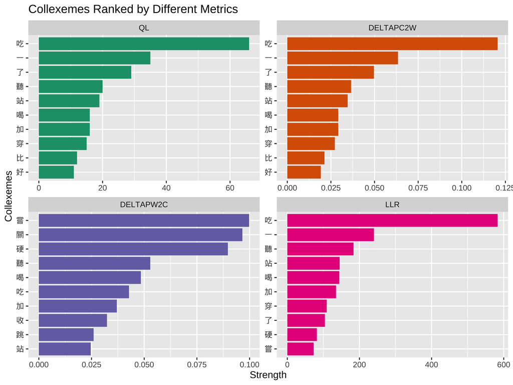

```r
## from wide to long
collo_table %>%
  filter(RELATION == "attraction") %>%
  filter(QL >=5) %>%
  select(WORD, QL,
         DELTAPC2W,
         DELTAPW2C,
         LLR) %>%
  pivot_longer(cols=c("QL",
                      "DELTAPC2W",
                      "DELTAPW2C",
                      "LLR"),
               names_to = "METRIC",
               values_to = "STRENGTH") %>%
  mutate(METRIC = factor(METRIC,
                         levels = c("QL",
                                   "DELTAPC2W",
                                   "DELTAPW2C",
                                   "LLR"))) %>%
  group_by(METRIC) %>%
  top_n(10, STRENGTH) %>%
  ungroup %>%
  arrange(METRIC, desc(STRENGTH)) -> coll_table_long

## plot
coll_table_long %>%
    mutate(WORD = reorder_within(WORD, within= METRIC, by=STRENGTH)) %>%
    ggplot(aes(WORD, STRENGTH, fill=METRIC)) +
    geom_col(show.legend = F) +
    scale_fill_brewer(palette = "Dark2") +
    coord_flip() +
    facet_wrap(~METRIC,scales = "free") +
    tidytext::scale_x_reordered() +
    labs(x = "Collexemes",
         y = "Strength",
         title = "Collexemes Ranked by Different Metrics")
```

The bar plots above show the top 10 collexemes based on four different metrics: `QL`, `DELTAPC2W`, `DELTAPW2C`, and `LLR`.

Please review the assigned readings for details on how **collostructional strengths** are calculated. In particular, Stefanowitsch & Gries (2003) explains why Fisher’s exact test-based measures provide advantages over raw frequency counts.

Also note that **delta P** is a directional association measure that has been increasingly used in psycholinguistic research (see Ellis (2006); Stefan Th Gries (2013)).

It is important to understand both how delta P is computed and how it should be interpreted.

[output not shown]

[output cut: 19 more lines]

[output not shown]

[output cut: 25 more lines]

[output not shown]

## 10 Distinctive Collexeme Analysis

We can also use Stefan Gries’ script `coll.analysis.r` to perform a **Distinctive Collexeme Analysis**.

To illustrate this method, let’s use data from the following study:

> Huang, P. W., & Chen, A. C. H. (2022). Degree adverbs in spoken Mandarin: A behavioral profile corpus-based approach to language alternatives. *Concentric: Studies in Linguistics*, 48(2), 285–322.

In this work, the focus is on differences among four Mandarin degree adverbs: `很`, `蠻/滿`, `超`, and `太`.

As before, we run the interactive function `coll.analysis()`.

For a **Distinctive Collexeme Analysis**, the input should be a data frame that lists each construction token in the corpus, with two key columns:

1. The **collexeme** (the co-occurring word)
2. The **constructional element** (the construction category being compared)

In our case, the constructional elements are the degree adverbs, and the collexemes are their co-occurring modifyees.

The following figure shows how these were annotated in concordance lines:

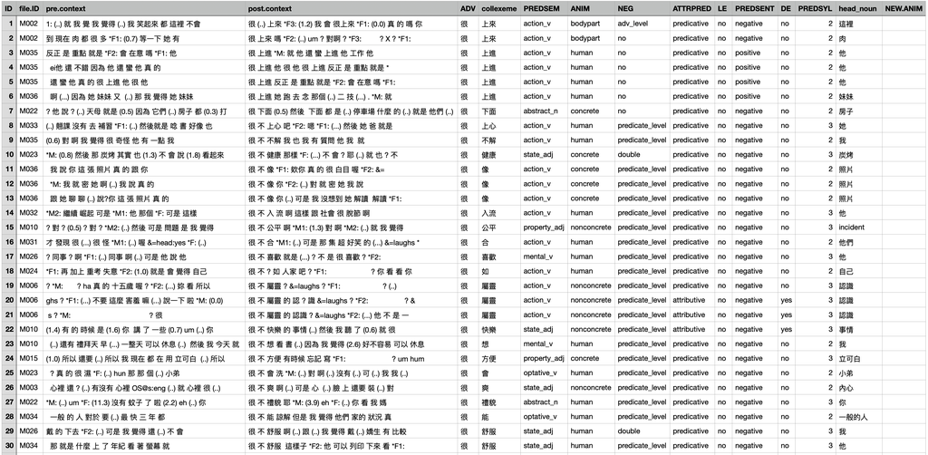

For Stefan’s script, we only need these two columns from the data: the collexemes and their associated constructional element.

| CONSTRUCTION | WORD |
| --- | --- |
| 太 | 快 |
| 太 | 賺 |
| 太 | 多 |
| 太 | 甜 |
| 太 | 多 |
| 太 | 好奇 |
| 太 | 甜 |
| 太 | 近 |
| 太 | 大 |
| 太 | 一樣 |

[output cut: 30 more lines]

Once the script runs, it generates the results as a tab-delimited CSV file in the root directory.

An example output file is included in this project.

```r
### Distinctive Collexeme Analysis: Results Exploration
dist_results <- read_tsv("2025-10-02 04-10-56.334203.csv")

dist_results
```

| COLLOCATE | 太 | 很 | 蠻 | 超 | SUMABSDEV | LARGESTPREF |
| --- | --- | --- | --- | --- | --- | --- |
| 一樣 | 5.99873305 | -2.22726641 | 0.53233597 | -0.82832020 | 9.5866556 | 太 |
| 誇張 | 3.28709279 | -1.66576285 | -1.56450814 | 2.46596421 | 8.9833280 | 太 |
| 溫暖 | 5.40038884 | -1.68365515 | -0.58104374 | -0.62615122 | 8.2912389 | 太 |
| 甜 | 4.42328529 | -1.12109852 | -0.82171993 | -0.88551154 | 7.2516153 | 太 |
| 舊 | 4.67687392 | -1.45808813 | -0.50319864 | -0.54226286 | 7.1804236 | 太 |
| 賺 | 2.92738420 | -1.45808813 | 1.48408815 | -0.54226286 | 6.4118233 | 太 |
| 可能 | 3.88528629 | -1.08970930 | -0.58104374 | -0.62615122 | 6.1821905 | 太 |
| 胖 | 3.32752045 | -1.35114236 | -0.64962665 | 0.72839404 | 6.0566835 | 太 |
| 嚴重 | 2.28060673 | -1.12109852 | 1.61219936 | -0.88551154 | 5.8994162 | 太 |
| 去 | 3.81865157 | -1.19052398 | -0.41085997 | -0.44275577 | 5.8627913 | 太 |

[output cut: 433 more lines]

In *distinctive collexeme analysis*, the two columns mean:

**`SUMABSDEV`** shows how unevenly a word appears across the constructions. The larger this number, the more the word favors one construction over the others.

**`LARGESTPREF`** tells you *which* construction the word favors most — the one where it appears more often than expected.

So, if a collocate has a high `SUMABSDEV` and `LARGESTPREF = A`, it means the word occurs much more often in Construction A than chance would predict.

And our next step is to explore the semantic patterns from the output:

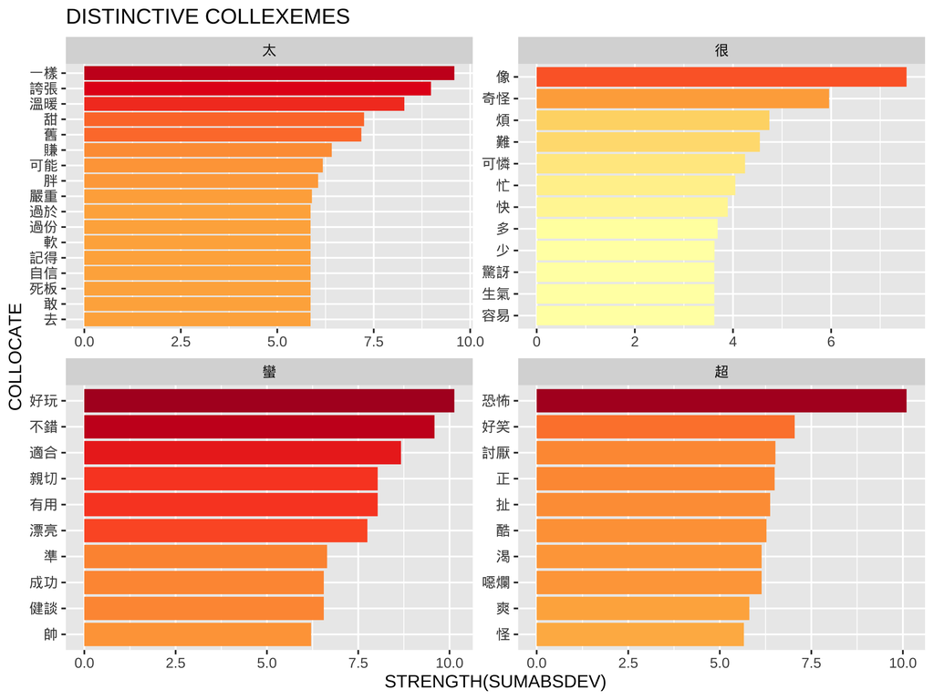

```r
dist_results %>%
  group_by(LARGESTPREF) %>%
  top_n(10, SUMABSDEV) %>%
  select(COLLOCATE, SUMABSDEV, LARGESTPREF) %>%
  ungroup %>%
  arrange(LARGESTPREF) %>%
  mutate(COLLOCATE = reorder_within(COLLOCATE, within= LARGESTPREF, by=SUMABSDEV)) %>%
  ggplot(aes(COLLOCATE, SUMABSDEV, fill=SUMABSDEV)) +
    geom_col(show.legend = F) +
    scale_fill_distiller(palette="YlOrRd", direction=1)+
    coord_flip() +
    facet_wrap(~LARGESTPREF,scales = "free") +
    tidytext::scale_x_reordered() +
    labs(x = "COLLOCATE",
         y = "STRENGTH(SUMABSDEV)",
         title = "DISTINCTIVE COLLEXEMES")
```

## References

Ellis, N. C. (2006). Language acquisition as rational contingency learning. *Applied Linguistics*, *27*(1), 1–24.

Gries, Stefan Th. (2013). 50-something years of work on collocations: What is or should be next…. *International Journal of Corpus Linguistics*, *18*(1), 137–166.

Gries, Stefan T., & Stefanowitsch, A. (2004). Extending collostructional analysis: A corpus-based perspective onalternations’. *International Journal of Corpus Linguistics*, *9*(1), 97–129.

Stefanowitsch, A., & Gries, S. T. (2003). Collostructions: Investigating the interaction of words and constructions. *International Journal of Corpus Linguistics*, *8*(2), 209–243.

Stefanowitsch, A., & Gries, S. T. (2005). Covarying collexemes. *Corpus Linguistics and Linguistic Theory*, (1), 1–43.